# Task 1 – Gradient Descent using NumPy (20%)

## Part 1 (6 marks):

1. $ f(r) = \frac{{(r - 7)^3}}{3} $

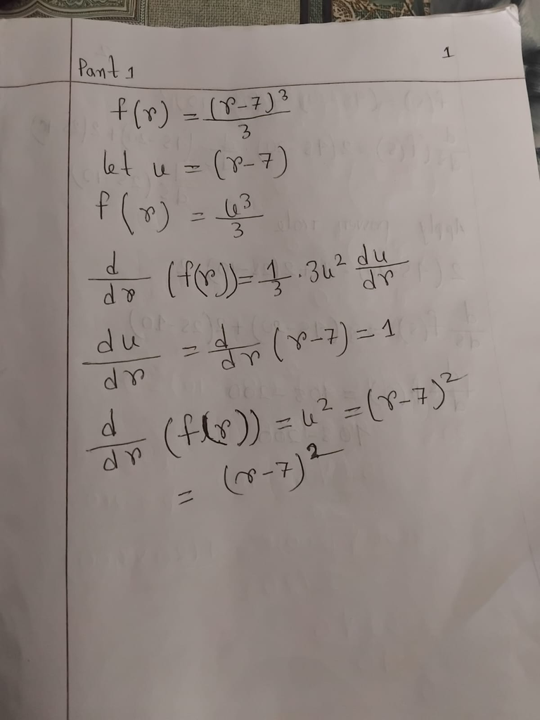

To differentiate this function $ f(r) $ with respect to $ r $, we'll use the power rule and chain rule. The power rule states that if we have a term of the form $ (u)^n $, its derivative is $ n \cdot (u)^{n-1} $. The chain rule states that if we have a composite function $ f(g(x)) $, its derivative is $ f'(g(x)) \cdot g'(x) $.

Let $ u = r - 7 $. Then $ f(r) = \frac{{u^3}}{3} $.

$\frac{d}{dr}f(r) = \frac{d}{dr}\left(\frac{u^3}{3}\right) = \frac{1}{3} \cdot \frac{d}{dr}(u^3) $

Applying the power rule to $ u^3 $:

$\frac{d}{dr}f(r) = \frac{1}{3} \cdot 3u^2 \cdot \frac{du}{dr} $

Now, $ \frac{du}{dr} = \frac{d}{dr}(r - 7) = 1 $.

Therefore,

$\frac{d}{dr}f(r) = u^2 = (r - 7)^2 $

So, the derivative of $ f(r) $ with respect to $ r $ is $ (r - 7)^2 $.

2. $ f(s) = (4s - 20)^2 + (2s - 10)^2 $

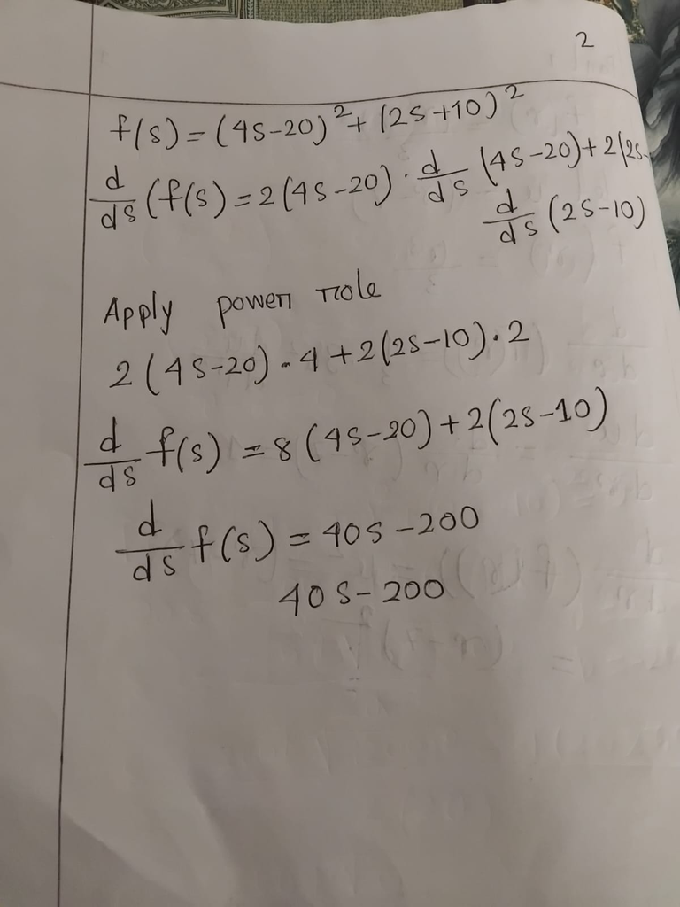

   To differentiate this function $ f(s) $ with respect to $ s $, we'll apply the power rule.

   $\frac{d}{ds}f(s) = 2(4s - 20) \cdot \frac{d}{ds}(4s - 20) + 2(2s - 10) \cdot \frac{d}{ds}(2s - 10) $

   Applying the power rule to $ (4s - 20) $ and $ (2s - 10) $:

   $\frac{d}{ds}f(s) = 2(4s - 20) \cdot 4 + 2(2s - 10) \cdot 2 $

   Simplifying,

   $\frac{d}{ds}f(s) = 8(4s - 20) + 4(2s - 10) $

   $\frac{d}{ds}f(s) = 32s - 160 + 8s - 40 $

   $\frac{d}{ds}f(s) = 40s - 200 $

   So, the derivative of $ f(s) $ with respect to $ s $ is $ 40s - 200 $.
3. $ f(t) = \left(\frac{{4t^2}}{t} - 12\right)^2 $

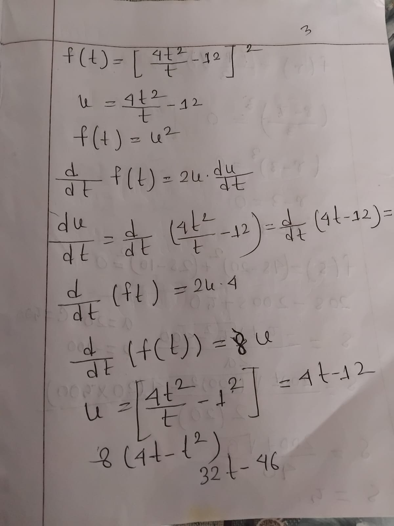

   To differentiate this function $ f(t) $ with respect to $ t $, we'll again apply the power rule.

   Let $ u = \frac{{4t^2}}{t} - 12 $. Then $ f(t) = u^2 $.

   $\frac{d}{dt}f(t) = 2u \cdot \frac{du}{dt} $

   Now, $ \frac{du}{dt} = \frac{d}{dt}\left(\frac{{4t^2}}{t} - 12\right) = \frac{d}{dt}(4t - 12) = 4 $.

   Therefore,

   $\frac{d}{dt}f(t) = 2u \cdot 4 $

   $\frac{d}{dt}f(t) = 8u $

   Now, $ u = \frac{{4t^2}}{t} - 12 = 4t - 12 $.

   So,

   $\frac{d}{dt}f(t) = 8(4t - 12) $

   $\frac{d}{dt}f(t) = 32t - 96 $

   So, the derivative of $ f(t) $ with respect to $ t $ is $ 32t - 96 $.

## Part 2 (12 marks):

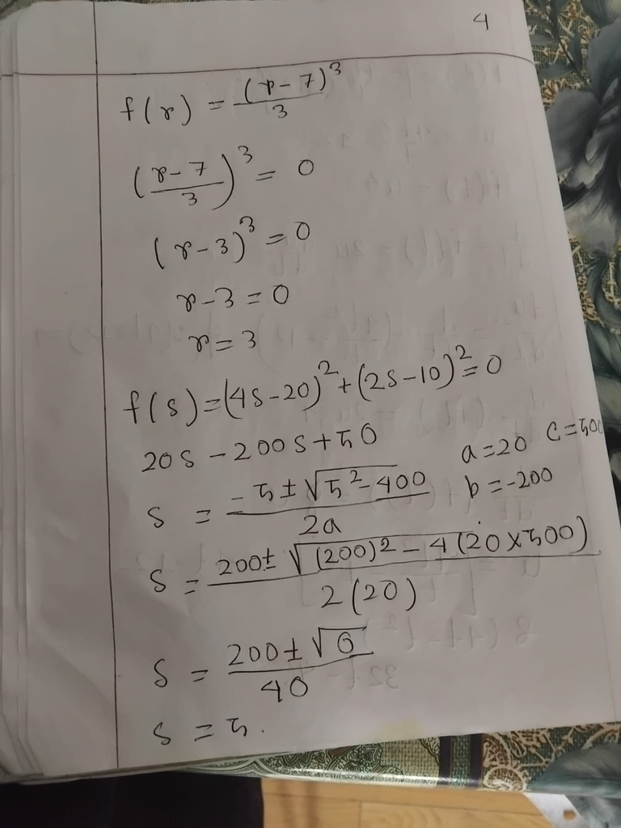

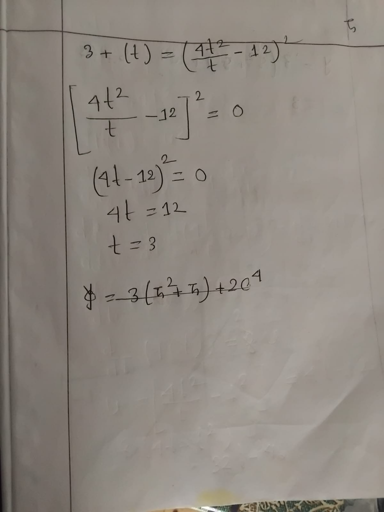

## Part 2b (2 marks):

To find the true values of $ r $, $ s $, and $ t $ such that $ E = y^2 = 0 $, we need to solve the equation $ E(r, s, t) = 0 $ analytically. This means finding the exact solutions where the error function is equal to zero.

Given the error function $ E = y^2 $, where $ y = f(r, s, t) = (r - 7)^3 + (4s - 20)^2 + (2s - 10)^2 + \left(\frac{{4t^2}}{t} - 12\right)^2 $, we need to solve $ y = 0 $ to find the true values of $ r $, $ s $, and $ t $ where $ E = 0 $.

$ (4s - 20)^2 = 0 $ $ 4s - 20 = 0 $ $ s - 5 = 0 $ $ s = 5 $

$ (2s - 10)^2 = 0 $ $ 2s - 10 = 0 $ $ s - 5 = 0 $ $ s = 5 $

So, $ s = 5 $.

These are the exact solutions where the error function is equal to zero, verified mathematically.